# Graddy IV

Erick Rosas

12/8/2021

## Fish Markets and Instrumental Variables (Work in *Slow* Progress)

For this problem, use the dataset “fish.dta”. The data was used in Graddy (1995) and Angrist, Graddy and Imbens (2000). It was obtained from a single dealer of whiting at the Fulton fish market. He supplied his inventory sheets for the period of December 1991 through May 1992.The market is open Monday through Friday. Make beautiful tables and beautiful figures if you can.

```r
library(foreign)
library(tidyverse)
library(stargazer)
library(kableExtra)
library(lfe)
library(ivreg)

fish <- read.dta("https://github.com/scunning1975/causal-inference-class/blob/master/Assignments/Assignments/FISH.dta?raw=true")
```

**Consider the following demand equation:**

$$Quantity_t=β_0+β_1 Price_t+β_2 mon_t+ β_3 tue_t+ β_4 Wed_t+β_5 Thurs_t+β_6 Time_t+ ε_t$$

**Run this regression using ordinary least squares with the command “reg” and report the estimated coefficient, standard error, and p-value on price. Interpret the coefficient on price. Why would we be concerned that the estimated coefficient on price is not a consistent estimate of the causal effect of price on the demand for whiting?**

```r
ols <- lm(quantity ~ .,fish %>% select(-(speed2:wave3)))
stargazer(ols,type="html",omit = c("Constant","mon","tues","wed","thurs","time"),dep.var.caption = "")
```

|  | quantity |
| --- | --- |
| price | -2,484.703*** |
|  | (742.048) |
| Observations | 97 |
| R<sup>2</sup> | 0.225 |
| Adjusted R<sup>2</sup> | 0.174 |
| Residual Std. Error | 2,382.068 (df = 90) |
| F Statistic | 4.366*** (df = 6; 90) |
| *Note:* | p<0.1; p<0.05; p<0.01 |

```r
# modelsummary::modelsummary(ols)
```

The regression results show a value of -2484.7025369 on the price regressor. That means that the law of Marshall is observed, since an increase of 1 dollar in price induces a quantity change of -2484.7025369 pounds of whiting.

This estimate might not be causal because of the identification problem: Price and quantity are simultaneously determined in equilibria, so we’d need exogenous variation (supply shocks) to determine correctly our $\beta_1$.

**Why would we want to include day of the week indicators in the regression? Why would we want to include a time trend in the regression?**

This is to capture intraweekly and seasonal variations that may confound the relationship between quantity and price (e.g. with days of more intensive activity in the market and days with less; or variations in price as time passes). This is illustrated in the following two graphs.

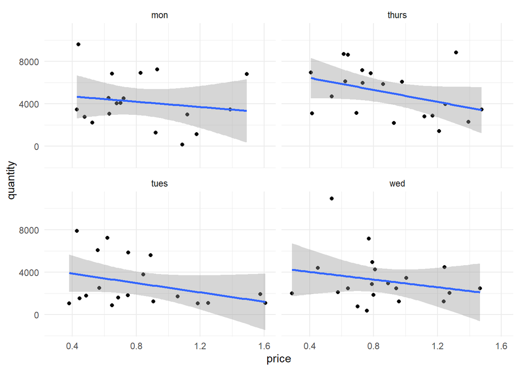

```r
fish %>%
  pivot_longer(mon:thurs,names_to = "day") %>% filter(value==1) %>%
  ggplot(aes(x=price,y=quantity)) +
  geom_point() +
  geom_smooth(method="lm")+
  facet_wrap(~day)+
  theme_minimal()
```

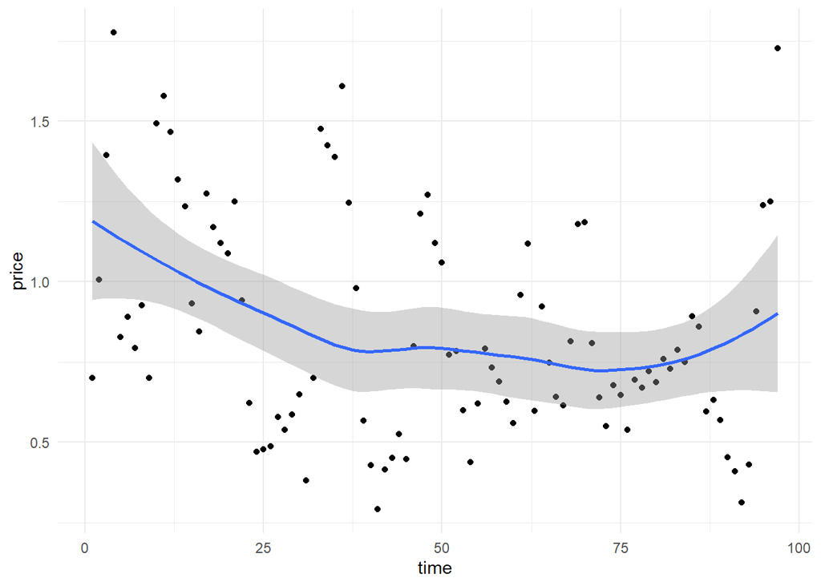

```r
fish %>%
  ggplot(aes(x=time,y=price)) +
  geom_point() +
  geom_smooth()+
  theme_minimal()
```

**Consider using wave2, the average over the past two days of the observed maximum wave height for the day, as an instrument for the price of whiting. Explain why this might be a valid instrument. Why is this “strange”?**

Weather information such as wave height might constitute an exogenous variation on supply, affecting fishers and thus the price they sell at in the Fulton market. The *strangeness* of such an instrument derives in that demand is *not* affected by the weather: I still want to eat fish, independently if I waves are high or low.

However, if there were close substitutes to whiting, Such an instrument might violate the exclusion restriction, because of general ewquilibrium effects that might end up affecting the quantity demanded through weather shocks.That doesn’t seem to be the case here.

**Run the first stage regression using ordinary least squares (OLS):**

$$Price_t= α_0+ α_1 wave2_t+ α_3 mon_t+ α_4 tue_t+α_5 wed_t+ α_6 thurs_t+ α_7 time_t+ ω_t$$

```r
fs <- lm(price ~ .,fish %>% select(-(speed2:wave3),wave2,-quantity))
stargazer(fs,type="html",omit = c("Constant","mon","tues","wed","thurs","time"),dep.var.caption = "")
```

|  | price |
| --- | --- |
| wave2 | 0.099*** |
|  | (0.018) |
| Observations | 97 |
| R<sup>2</sup> | 0.329 |
| Adjusted R<sup>2</sup> | 0.284 |
| Residual Std. Error | 0.291 (df = 90) |
| F Statistic | 7.357*** (df = 6; 90) |
| *Note:* | p<0.1; p<0.05; p<0.01 |

**Is wave2 a strong instrument? What is the F statistic on the excludability of the instrument from the first stage?**

```r
fs.strength <- summary(fs)$coefficients["wave2",]
names(fs.strength)[3] <- "F-statistic"
fs.strength[3] <- fs.strength[3]^2
fs.strength[1:3] <- fs.strength[1:3] %>% round(3)

knitr::kable(fs.strength %>% t()) %>% kable_styling()
```

| Estimate | Std. Error | F-statistic | Pr(>\|t\|) |
| --- | --- | --- | --- |
| 0.099 | 0.018 | 31.638 | 2e-07 |

The estimate of $wave2$ is significant. The F-statistic is above 10, so it might be a strong instrument. The first stage does influence price and the variation it induces on price could be a good instrument to estimate its effect on quantity.

**Report the IV estimate of the effect of price on quantity using wave2 as an instrumental variable. How does this compare to the OLS estimate of the association between price and quantity? (is it the same, larger, smaller?). Provide an intuitive explanation of why your OLS estimate is different from your IV estimate.**

```r
fish$fitted <- fs$fitted.values # price hat!

# from Wald statistic, we need reduced form
rf <- lm(quantity ~ .,fish %>% select(-(speed2:wave3),-price,-fitted,wave2))
wald <- rf$coefficients["wave2"]/fs.strength[1]

# wald #-3581.383

# manual 2SLS
iv.manual <- lm(quantity ~ .,fish %>% select(-(speed2:wave3),-price))
# summary(iv.manual) #-3581.383 too!

iv <- ivreg(formula=quantity ~ price+mon+tues+wed+thurs+time|mon+tues+wed+thurs+time+wave2,data=fish)
# summary(iv) #same with correct standard errors

stargazer(iv.manual,iv,ols,
          type="html",
          omit = c("Constant","mon","tues","wed","thurs","time"),
          dep.var.caption = "",
          column.labels = c("Manual 2SLS","","original"))
```

|  | quantity |  |  |
| --- | --- | --- | --- |
|  | *OLS* | *instrumental* | *OLS* |
|  |  | *variable* |  |
|  | Manual 2SLS |  | original |
|  | (1) | (2) | (3) |
| price |  | -3,581.383** | -2,484.703*** |
|  |  | (1,472.552) | (742.048) |
| fitted | -3,581.383** |  |  |
|  | (1,496.079) |  |  |
| Observations | 97 | 97 | 97 |
| R<sup>2</sup> | 0.181 | 0.207 | 0.225 |
| Adjusted R<sup>2</sup> | 0.127 | 0.154 | 0.174 |
| Residual Std. Error (df = 90) | 2,449.318 | 2,410.801 | 2,382.068 |
| F Statistic (df = 6; 90) | 3.317*** |  | 4.366*** |
| *Note:* | p<0.1; p<0.05; p<0.01 |  |  |

As we can see in the table, the effect estimated by instrumenting for wave heights is larger in absolute value. This can be due to many reasons: when we estimate with instrumental variables we are estimating an effect on those observations that were treated, subject to this exogenous variation. Since they are due to shocks in weather, they might have a more intense reaction.

**Report the estimated own-price demand elasticity of whiting using wave2 as the instrument.**

```r
ols.ln <- lm(I(log(quantity)) ~ .,fish %>% mutate(ln.price=log(price))
             %>% select(-(speed2:wave3),-price,-fitted))
iv.manual.ln <- lm(I(log(quantity)) ~ .,fish %>% mutate(ln.fitted=log(fitted)) %>% select(-(speed2:wave3),-price,-fitted))

iv.ln <- ivreg(formula=I(log(quantity)) ~ I(log(price))+mon+tues+wed+thurs+time|mon+tues+wed+thurs+time+wave2,data=fish)

stargazer(iv.manual.ln,iv.ln,ols.ln,
          type="html",
          omit = c("Constant","mon","tues","wed","thurs","time"),
          dep.var.caption = "",
          column.labels = c("Manual 2SLS","","original"),
          dep.var.labels = "Log quantity")
```

|  | Log quantity |  |  |
| --- | --- | --- | --- |
|  | *OLS* | *instrumental* | *OLS* |
|  |  | *variable* |  |
|  | Manual 2SLS |  | original |
|  | (1) | (2) | (3) |
| I(log(price)) |  | -0.960** |  |
|  |  | (0.422) |  |
| ln.fitted | -0.930** |  |  |
|  | (0.386) |  |  |
| ln.price |  |  | -0.549*** |
|  |  |  | (0.184) |
| Observations | 97 | 97 | 97 |
| R<sup>2</sup> | 0.194 | 0.175 | 0.219 |
| Adjusted R<sup>2</sup> | 0.140 | 0.120 | 0.167 |
| Residual Std. Error (df = 90) | 0.709 | 0.717 | 0.698 |
| F Statistic (df = 6; 90) | 3.603*** |  | 4.201*** |
| *Note:* | p<0.1; p<0.05; p<0.01 |  |  |

The elasticity is much bigger when using instrumented variables.

**Consider using speed3, the maximum wind speed from three days earlier, as the instrument for price instead of wave2. Using only speed3 run the 1st-stage regression. Is speed3 a strong instrument (using the F-test)?**

I estimate this equation:

$$Price_t= α_0+ α_1 speed3_t+ α_3 mon_t+ α_4 tue_t+α_5 wed_t+ α_6 thurs_t+ α_7 time_t+ ω_t$$

```r
fs2 <- lm(price ~ .,fish %>% select(-(speed2:wave2),-wave3,-quantity,-fitted))
stargazer(fs2,type="html",omit = c("Constant","mon","tues","wed","thurs","time"),dep.var.caption = "")
```

|  | price |
| --- | --- |
| speed3 | 0.015*** |
|  | (0.005) |
| Observations | 97 |
| R<sup>2</sup> | 0.166 |
| Adjusted R<sup>2</sup> | 0.111 |
| Residual Std. Error | 0.324 (df = 90) |
| F Statistic | 2.991** (df = 6; 90) |
| *Note:* | p<0.1; p<0.05; p<0.01 |

The F-test is computed to assess the strength of this instrument.

```r
fs.strength2 <- summary(fs2)$coefficients["speed3",]
names(fs.strength2)[3] <- "F-statistic"
fs.strength2[3] <- fs.strength2[3]^2
fs.strength2[1:3] <- fs.strength2[1:3] %>% round(3)

knitr::kable(fs.strength2 %>% t()) %>% kable_styling()
```

| Estimate | Std. Error | F-statistic | Pr(>\|t\|) |
| --- | --- | --- | --- |
| 0.015 | 0.005 | 7.885 | 0.0061127 |

The estimate of $speed3$ is significant. However, the F-statistic is below 10, so it might be a weak(er) instrument. The first stage does influence price and the variation it induces on price could be a good instrument to estimate its effect on quantity.

**Summarize this exercise in a professional-looking table like the one I shared in dropbox with all the same columns and rows, labeled correctly, but using the two different instruments (wave2 in column 2 and speed3 in column 3).**

*ask Scott for table*

```r
# iv.manual.ln <- lm(I(log(quantity)) ~ .,fish %>% mutate(ln.fitted=log(fitted)) %>% select(-(speed2:wave3),-price,-fitted))

iv.ln2 <- ivreg(formula=I(log(quantity)) ~ I(log(price))+mon+tues+wed+thurs+time|mon+tues+wed+thurs+time+speed3,data=fish)

stargazer(ols.ln,iv.ln,iv.ln2,
          type="html",
          omit = c("Constant","mon","tues","wed","thurs","time"),
          dep.var.caption = "",
          column.labels = c("original","waves","winds"),
          dep.var.labels = "Log quantity")
```

|  | Log quantity |  |  |
| --- | --- | --- | --- |
|  | *OLS* | *instrumental* |  |
|  |  | *variable* |  |
|  | original | waves | winds |
|  | (1) | (2) | (3) |
| I(log(price)) |  | -0.960** | -1.960** |
|  |  | (0.422) | (0.907) |
| ln.price | -0.549*** |  |  |
|  | (0.184) |  |  |
| Observations | 97 | 97 | 97 |
| R<sup>2</sup> | 0.219 | 0.175 | -0.291 |
| Adjusted R<sup>2</sup> | 0.167 | 0.120 | -0.377 |
| Residual Std. Error (df = 90) | 0.698 | 0.717 | 0.897 |
| F Statistic | 4.201*** (df = 6; 90) |  |  |
| *Note:* | p<0.1; p<0.05; p<0.01 |  |  |

**Discuss why your IV estimates in columns (2) and (3) differed from one another. How does this shed light on our discussion of the local average treatment effect (LATE) parameter?**

Even though wind speed, judging by the F-statistic, was a “worse” instrument than wave height, it induced a bigger change on the causal estimate. It might be because we are impacting on anoyher set of observations being exposed to variation thanks to wind speed, and their effect might be as well estimated as the one instrumenting for waves. This speaks of the limitations of LATE: unobservables will remain unobservable.